# Central Limit Theorem applied to Exponential Distribution

Leandro GARCIA

# OVERVIEW

In this project we will investigate the exponential distribution in R and compare it with the Central Limit Theorem.

# PROCEDURE

The exponential distribution is simulated in R with `rexp(n, lambda)` where lambda is the rate parameter. The *mean ($\mu$)* of exponential distribution is *$\frac{1}{\lambda}$* and the *standard deviation ($\sigma$)* is also *$\frac{1}{\lambda}$*. For all the simulation, lambda is set to 0.2. We will simulate 1000 sample means, using 40 exponentials.

# THEORETICAL VALUES

In this section we calculate the theoretical values for the exponential distribution distribution

## Theoretical Mean: ( $\mu_{t} = \frac{1}{\lambda}$ )

```r
mu_t
```

```
[1] 5
```

Theoretical mean ( $\mu_{t} = 5.0$ )

## Theoretical Standard Desviation ( $\sigma_{t} = \frac{1}{\lambda}$ )

```r
sigma_t # 5.0
```

```
[1] 5
```

Theoretical Standard Deviation: ( $\sigma_{t} = 5.0$ )

## Theoretical Variance ( $Var_{t} = \sigma^2$ )

```r
var_t # 25.0
```

```
[1] 25
```

Theoretical Variance: ( $Var_{t} = 25.0$ )

## Theoretical Standard Error of the mean : ( $SE_{\overline{X}} = \frac{\sigma}{\sqrt(n)}$ )

```r
SE_t # 25.0
```

```
[1] 0.7905694
```

Theoretical Standar Error of the mean : ( $SE_{\overline{X}} = 0.79$ )

# PRACTICAL VALUES

In this section we calculate the random values of the distribution, and then we will proceed to retrieve the initial parameter (inference).

## SIMULATING

Getting the values to Simulate 1000 times 40 $X_{1 \dots 40}$, and then obtain 1000 $\overline{X}_{i}$ or in other words $\overline{X}_{1 \dots 1000}$

```r
# Simulated means based on the parameters
str(means)
```

```
 num [1:1000] 4.6 6.02 5.46 4.18 7.14 ...
```

## Practical mean: ( $\mu_{p} = \sum_{i=1}^{1000}\frac{\overline{X}_{i}}{n}$ )

```r
mu_p
```

```
[1] 4.974239
```

Practical mean: ( $\mu_{p} = 4.97$ )

## Practical Standard Error of the mean: ( $SE_{\overline{X}} = \sigma_{\overline{X}}$ )

```r
SE_p
```

```
[1] 0.7713431
```

Practical Standard Error of the mean: ( $SE_{\overline{X}} = 0.77$ )

## Practical Population Standard Deviation: ($\sigma_{p} = SE_{\overline{X}} * \sqrt(n)$ )

```r
sigma_p
```

```
[1] 4.878402
```

Practical Population Standard Deviation: ($\sigma_{p} = 4.88$ )

## Practical Population Variance: ( $Var_{p} = \sigma^2$ )

```r
var_p
```

```
[1] 23.79881
```

Practical Population Variance: ( $Var_{p} = 23.8$ )

# THEORETICAL VALUES Vs. PRACTICAL VALUES

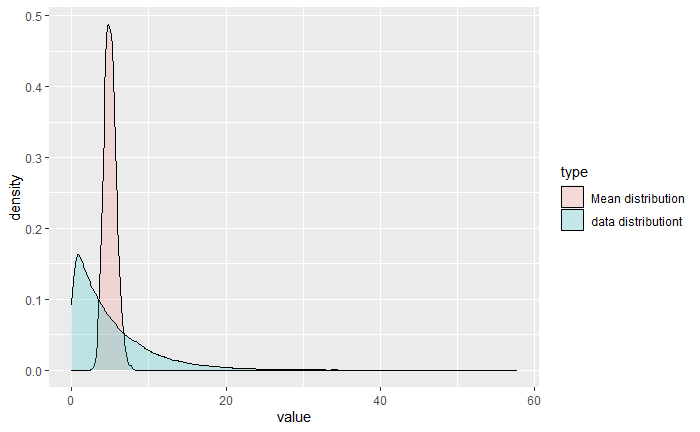

[output not shown]

# CONCLUSIONS:

Using random values of a exponential distribution, we were able to :